# Data Visualization: COVID-19 Detour

Prof. Harbert

# Disclaimer

The author of this page is not an epidemiologist. All data visualizations presented here are for code demonstration purposes only and are not meant to be a substitute for public health information. For current information we recommend: [the JHU Coronavirus dashboard](https://coronavirus.jhu.edu/map.html) and [Nextstrain](https://nextstrain.org/ncov)

# Data visualization: Coronavirus Data Trends

Goals

That’s it.

# The Raw Data

## Download GitHub Repo

The raw data compiled by Johns Hopkins University Center for Systems Science and Engineering and used in online [dashboards](https://coronavirus.jhu.edu/map.html) tracking the virus spread are publicly available in a [GitHub repository](https://github.com/CSSEGISandData/COVID-19).

Also check out the case data by age repo from data scientist [Clause Wilke](https://gist.github.com/clauswilke/0621446f461049a9556c8372d5bc8a9b).

We will clone the entire repository and access the data files within.

```r
system('git clone https://github.com/CSSEGISandData/COVID-19')
list.files('COVID-19')
```

```
## [1] "archived_data"                  "csse_covid_19_data"
## [3] "README.md"                      "who_covid_19_situation_reports"
```

## Explore

Inside this folder we have the current data from various government and international organizations tracking the spread of the Coronavirus. We will mostly use the ‘csse_covid_19_data’ which compiles the infection and death rates.

```r
list.files('COVID-19/csse_covid_19_data/csse_covid_19_time_series')
```

```
## [1] "README.md"                          "time_series_19-covid-Confirmed.csv"
## [3] "time_series_19-covid-Deaths.csv"    "time_series_19-covid-Recovered.csv"
```

# Visualize

## Read

Read case trends file:

```r
cases = read.csv('COVID-19/csse_covid_19_data/csse_covid_19_time_series/time_series_19-covid-Confirmed.csv')
colnames(cases)
```

```
##  [1] "Province.State" "Country.Region" "Lat"            "Long"
##  [5] "X1.22.20"       "X1.23.20"       "X1.24.20"       "X1.25.20"
##  [9] "X1.26.20"       "X1.27.20"       "X1.28.20"       "X1.29.20"
## [13] "X1.30.20"       "X1.31.20"       "X2.1.20"        "X2.2.20"
## [17] "X2.3.20"        "X2.4.20"        "X2.5.20"        "X2.6.20"
## [21] "X2.7.20"        "X2.8.20"        "X2.9.20"        "X2.10.20"
## [25] "X2.11.20"       "X2.12.20"       "X2.13.20"       "X2.14.20"
## [29] "X2.15.20"       "X2.16.20"       "X2.17.20"       "X2.18.20"
## [33] "X2.19.20"       "X2.20.20"       "X2.21.20"       "X2.22.20"
## [37] "X2.23.20"       "X2.24.20"       "X2.25.20"       "X2.26.20"
## [41] "X2.27.20"       "X2.28.20"       "X2.29.20"       "X3.1.20"
## [45] "X3.2.20"        "X3.3.20"        "X3.4.20"        "X3.5.20"
## [49] "X3.6.20"        "X3.7.20"        "X3.8.20"        "X3.9.20"
## [53] "X3.10.20"       "X3.11.20"       "X3.12.20"       "X3.13.20"
## [57] "X3.14.20"       "X3.15.20"       "X3.16.20"       "X3.17.20"
## [61] "X3.18.20"       "X3.19.20"
```

Read death trends file: (work with this later)

```r
deaths = read.csv('COVID-19/csse_covid_19_data/csse_covid_19_time_series/time_series_19-covid-Deaths.csv')
```

## Filter with dplyr

These tables are organized with one column for each date that they have tracked data. The R packages dplyr and ggplot2 do not work with this formatting exacly. Instead we need to rearrange so that each row contains only one value for cases/deaths and information in other columns about the geography and date that value applies to.

We also need to fix dates to an R compatible date format. With reshape2 and dplyr we can reorganize the data and convert date strings all at the same time:

```r
library(reshape2)
library(dplyr)
library(tibble)
library(stringr)

cases_df = melt(cases,
               id.vars=c('Province.State', 'Country.Region', 'Lat', 'Long'),
               measure.vars = grep('X', colnames(cases), value=T)
               ) %>%
  mutate(variable=str_replace(variable, "X", "")) %>%
  mutate(variable=as.Date(variable, "%m.%d.%y"))

deaths_df = melt(deaths,
               id.vars=c('Province.State', 'Country.Region', 'Lat', 'Long'),
               measure.vars = grep('X', colnames(cases), value=T)
               ) %>%
  mutate(variable=str_replace(variable, "X", "")) %>%
  mutate(variable=as.Date(variable, "%m.%d.%y"))
```

How would you use dplyr to filter for cases (or deaths) by geography (country and state)?

```r
#calculate running case total for each country by summing across state.province groups
cases_notnull = cases_df %>%
  group_by(Country.Region, variable) %>%
  summarize(total_cases=sum(value))

#oof, fix state abbreviations to names for US states:
us_cases = cases_df %>%
  filter(Country.Region == 'US') %>%
  mutate(Province.State = str_extract(Province.State, '\\b[^,]+$')) %>%
  mutate(Province.State = ifelse(Province.State %in% state.abb,
                                 state.name[match(Province.State, state.abb)],
                                 Province.State)
  ) %>%
  group_by(Province.State, variable) %>%
  summarize(total_cases=sum(value))

#Get data for US cases in Massachusetts
ma_cases = us_cases %>%
  filter(Province.State == 'Massachusetts')
```

## Global Trends

Plot Global case trend

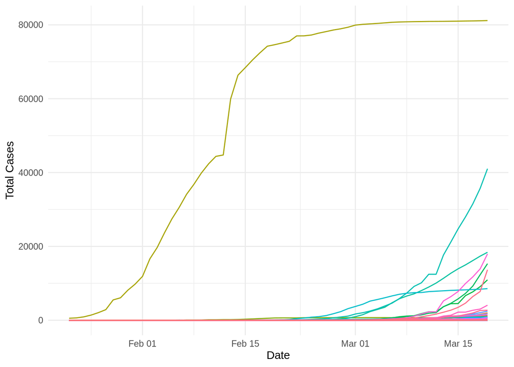

```r
library(ggplot2)
# turn off scientific notation, show real numbers:
options(scipen=999, digits=1)


ggplot(data=cases_notnull) +
  geom_path(aes(x=variable,
                y=total_cases,
                group=Country.Region,
                col=Country.Region)
            ) +
  theme_minimal() +
  theme(legend.position = 'none') +
  xlab('Date') +
  ylab('Total Cases')
```

China (the top line) dominates that graph so what if we make the same graph but without China:

```r
cases_notchina = cases_notnull %>%
  filter(Country.Region != "China")

country_plot = ggplot(cases_notchina) +
  geom_path(aes(x=variable,
                y=total_cases,
                group=Country.Region,
                col=Country.Region)
            ) +
  theme_minimal() +
  theme(legend.position = 'none') +
  xlab('Date') +
  ylab('Total Cases')
```

```r
label_cou = ggplot(cases_notchina) +
  geom_path(aes(x=variable,
                y=total_cases,
                group=Country.Region,
                col=Country.Region)
            ) +
  geom_text(data = cases_notchina %>% filter(variable == max(variable, na.rm=T)-1),
            aes(label = Country.Region, colour = Country.Region, x = max(variable, na.rm=T), y = total_cases), hjust = "inward") +
  scale_color_discrete() +
  theme_minimal() +
  theme(legend.position = 'none') +
  xlab('Date') +
  ylab('Total Cases')
```

## US Trends

Let’s apply the same thinking to plot the trend for all US States reporting cases:

Then plot:

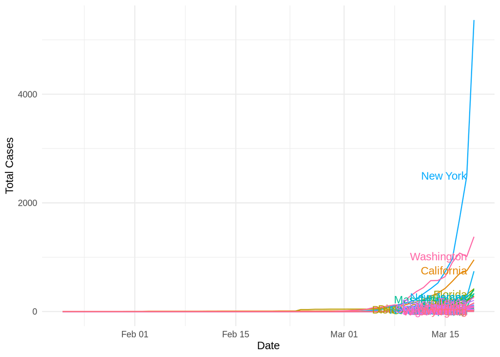

```r
state_plot =ggplot(us_cases) +
  geom_path(aes(x=variable,
                y=total_cases,
                group=Province.State,
                col=Province.State)
            ) +
  geom_text(data = us_cases %>% filter(variable == max(variable, na.rm=T)-1),
            aes(label = Province.State, colour = Province.State, x = max(variable, na.rm=T), y = total_cases), hjust = "inward") +
  theme_minimal() +
  theme(legend.position = 'none') +
  xlab('Date') +
  ylab('Total Cases')

state_plot
```

## MA Trends

What about the cases in Massachusetts only?

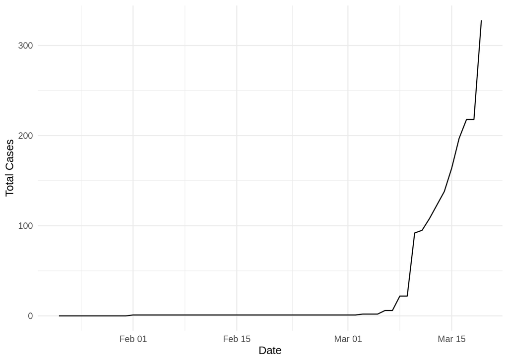

```r
ma_plot = ggplot(ma_cases) +
  geom_path(aes(x=variable,
                y=total_cases)
            ) +
  theme_minimal() +
  theme(legend.position = 'none') +
  xlab('Date') +
  ylab('Total Cases')

ma_plot
```

# Multipanel Plots

cowplot!

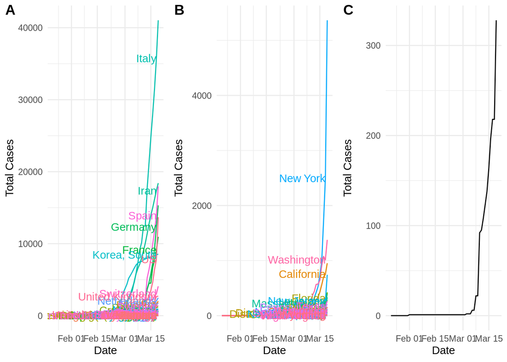

```r
library(cowplot)
cowplot = plot_grid(label_cou, state_plot, ma_plot, ncol=3, align = 'v', labels="AUTO")
cowplot
```

# Saving Plots

Use ggsave() to create image files of your ggplot images.

```r
dir.create('figures', showWarnings=F)
ggsave(cowplot, file='figures/corona_fig.png', height=6, width=12, units='in', dpi=600)
```

# Cumulative Infections Script

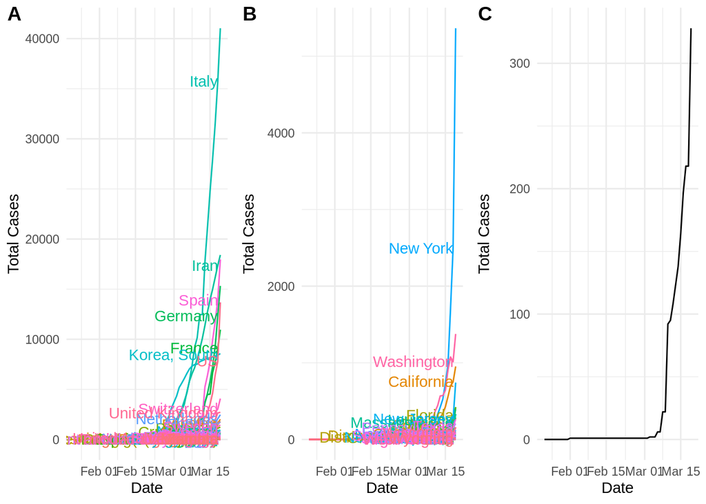

```r
#!/usr/bin/R
library(dplyr)
library(tibble)
library(ggplot2)
library(reshape2)
library(stringr)
library(cowplot)

#get data
system('git clone https://github.com/CSSEGISandData/COVID-19')

#load cases, deaths, recovered data
cases = read.csv('COVID-19/csse_covid_19_data/csse_covid_19_time_series/time_series_19-covid-Confirmed.csv')

cases_df = melt(cases,
               id.vars=c('Province.State', 'Country.Region', 'Lat', 'Long'),
               measure.vars = grep('X', colnames(cases), value=T)
               ) %>%
  mutate(variable=str_replace(variable, "X", "")) %>%
  mutate(variable=as.Date(variable, "%m.%d.%y"))

#calculate running case total for each country by summing across state.province groups
cases_notnull = cases_df %>%
  group_by(Country.Region, variable) %>%
  summarize(total_cases=sum(value))

cases_notchina = cases_notnull %>%
  filter(Country.Region != "China")

#oof, fix state abbreviations to names for US states:
us_cases = cases_df %>%
  filter(Country.Region == 'US') %>%
  mutate(Province.State = str_extract(Province.State, '\\b[^,]+$')) %>%
  mutate(Province.State = ifelse(Province.State %in% state.abb,
                                 state.name[match(Province.State, state.abb)],
                                 Province.State)
  ) %>%
  group_by(Province.State, variable) %>%
  summarize(total_cases=sum(value))

#Get data for US cases in Massachusetts
ma_cases = us_cases %>%
  filter(Province.State == 'Massachusetts')

#plot global trends
label_cou = ggplot(cases_notchina) +
  geom_path(aes(x=variable,
                y=total_cases,
                group=Country.Region,
                col=Country.Region)
            ) +
  geom_text(data = cases_notchina %>% filter(variable == max(variable, na.rm=T)-1),
            aes(label = Country.Region, colour = Country.Region, x = max(variable, na.rm=T), y = total_cases), hjust = "inward") +
  scale_color_discrete() +
  theme_minimal() +
  theme(legend.position = 'none') +
  xlab('Date') +
  ylab('Total Cases')

#plot US data
state_plot =ggplot(us_cases) +
  geom_path(aes(x=variable,
                y=total_cases,
                group=Province.State,
                col=Province.State)
            ) +
  geom_text(data = us_cases %>% filter(variable == max(variable, na.rm=T)-1),
            aes(label = Province.State, colour = Province.State, x = max(variable, na.rm=T), y = total_cases), hjust = "inward") +
  theme_minimal() +
  theme(legend.position = 'none') +
  xlab('Date') +
  ylab('Total Cases')

#plot MA data
ma_plot = ggplot(ma_cases) +
  geom_path(aes(x=variable,
                y=total_cases)
            ) +
  theme_minimal() +
  theme(legend.position = 'none') +
  xlab('Date') +
  ylab('Total Cases')


cowplot = plot_grid(label_cou, state_plot, ma_plot, ncol=3, align = 'v', labels="AUTO")
cowplot
```

```r
dir.create('figures', showWarnings=F)
ggsave(cowplot, file='figures/corona_fig.png', height=6, width=12, units='in', dpi=600)
```

# Critique:

While these graphs are informative they do NOT make it easy to view the trends of individual countries/states outside of those that have the highest values. We could muck around with the code to filter better to show countries/states of interest, but there may be better ways. In the next section we will experiment with code to generate interactive web-based graphics from ggplot code using ggplotly.